# PSY 4802- Quiz 4

Amanda Mae Woodward

2024-11-19

```r
library(ggplot2)
```

For this assignment, we’re going to use data that were collected by Rentfrow et al on the big five personality traits across regions of the U.S.

1. import the ANOVA OCEAN by state dataset

```r
oceanData <-  read.csv("~/Desktop/FA24 Syllabi:Schedules/PSY4802_Using_R_to_Create_Reproducible_Research/Quiz/ANOVA OCEAN by state.csv")
```

2. Find the correlation between openness scores (o) and extraversion (e)

```r
cor.test(oceanData$E, oceanData$O)
```

```
##
##  Pearson's product-moment correlation
##
## data:  oceanData$E and oceanData$O
## t = -1.1446, df = 47, p-value = 0.2582
## alternative hypothesis: true correlation is not equal to 0
## 95 percent confidence interval:
##  -0.426144  0.122173
## sample estimates:
##        cor
## -0.1646812
```

```r
#### the correlation is both relatively weak and negative, -0.16.
```

3. Create a graph to accompany your analysis.

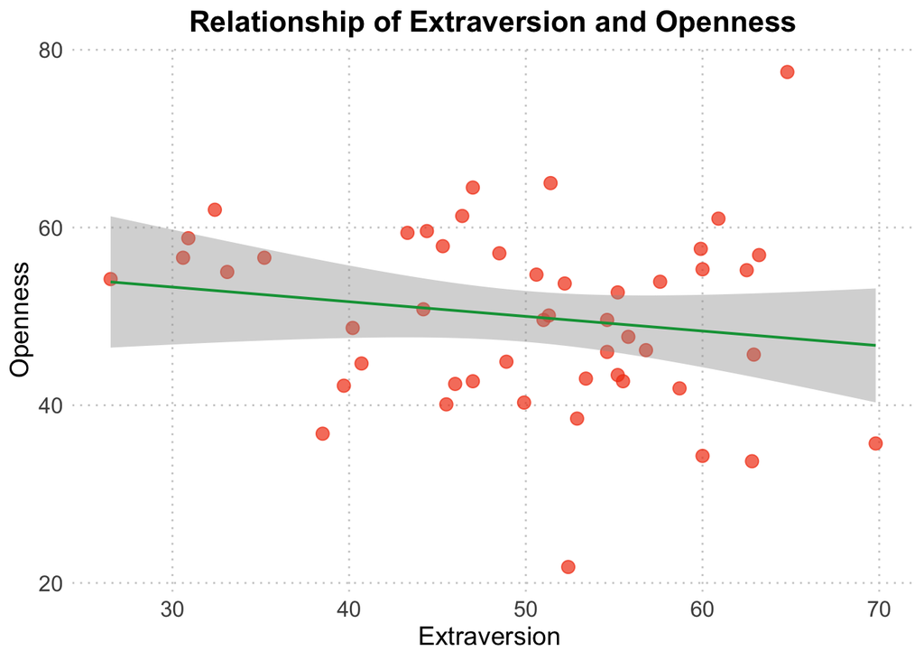

```r
# decorate graph
ggplot(oceanData, aes(x = E, y = O)) +
  geom_point(color = "#F34213", size = 3, alpha = 0.7) +
  geom_smooth(method = "lm", se = TRUE, color = "#08A045",size = 0.7) +
  labs(
    title = "Relationship of Extraversion and Openness",
    x = "Extraversion ",
    y = "Openness"
  ) +
  theme_minimal() +
  theme(
    plot.title = element_text(size = 16, face = "bold", hjust = 0.5),
    axis.title = element_text(size = 14),
    axis.text = element_text(size = 12),
    panel.grid.major = element_line(color = "gray80", linetype = "dotted"),
    panel.grid.minor = element_blank()
  )
```

4. Create a subset of your data containing only east coast and midwest data.

```r
regionalData <- subset(oceanData, Region %in% c("NE", "MW"))
```

5. Using this dataset, run a t test to determine if the agreeableness (A) levels differ between the midwest and east coast

```r
midwestDat <- subset(regionalData, Region == "MW")

eastCoastDat <- subset(regionalData, Region == "NE")

regionalT <- t.test(midwestDat$A, eastCoastDat$A, var.equal = FALSE)
print(regionalT)
```

```
##
##  Welch Two Sample t-test
##
## data:  midwestDat$A and eastCoastDat$A
## t = 3.495, df = 11.782, p-value = 0.004539
## alternative hypothesis: true difference in means is not equal to 0
## 95 percent confidence interval:
##   4.732146 20.484520
## sample estimates:
## mean of x mean of y
##  54.60833  42.00000
```

Based on the results of our t-test, we can state that the mean difference in agreeableness between residents of the Midwest and East Coast is not equal to zero and is in fact significantly different.

6. create a graph to illustrate your findings.

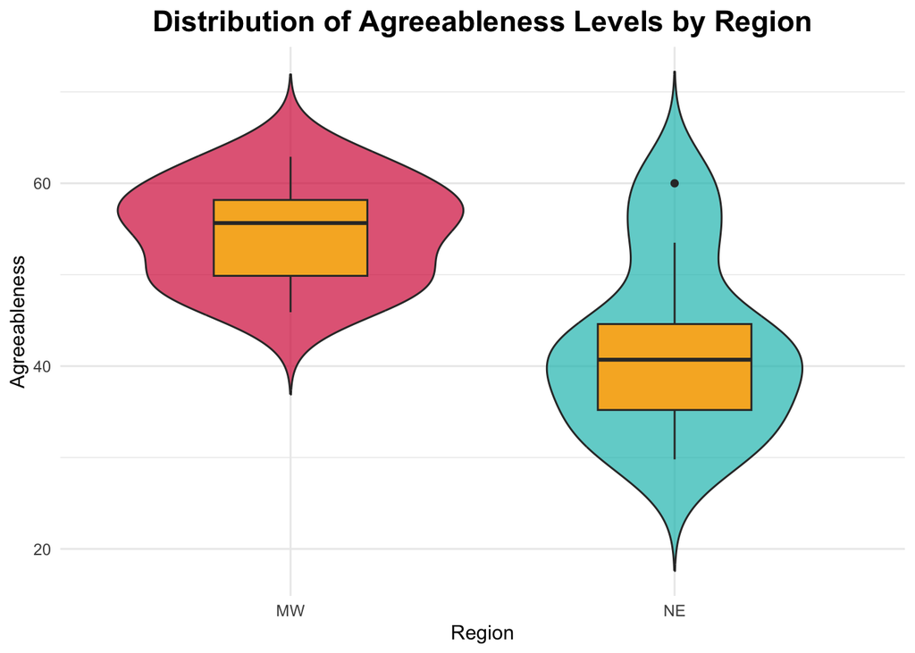

```r
ggplot(regionalData, aes(x = Region, y = A, fill = Region)) +
  geom_violin(trim = FALSE, alpha = 0.7) +
  geom_boxplot(width = 0.4, fill = "#F7B32B") +
  labs(
    title = "Distribution of Agreeableness Levels by Region",
    x = "Region",
    y = "Agreeableness"
  ) +
  theme_minimal() +
  scale_fill_manual(values = c("NE" = "#17BEBB", "MW" = "#D62246")) +
  theme(legend.position = "none",
        plot.title = element_text(size = 16, face = "bold", hjust = 0.5)
        )
```

7. create a subset of the original dataset containing data from the west and south.

```r
SW_subset <- subset(oceanData, Region %in% c("S","W"))
```

8. run a correlation between region and openness.

```r
corrResult <- aov(O ~ Region, data = oceanData)
summary(corrResult)
```

```
##             Df Sum Sq Mean Sq F value   Pr(>F)
## Region       3   1660   553.5   7.913 0.000241 ***
## Residuals   45   3148    70.0
## ---
## Signif. codes:  0 '***' 0.001 '**' 0.01 '*' 0.05 '.' 0.1 ' ' 1
```

9. create a graph to accompany this analysis

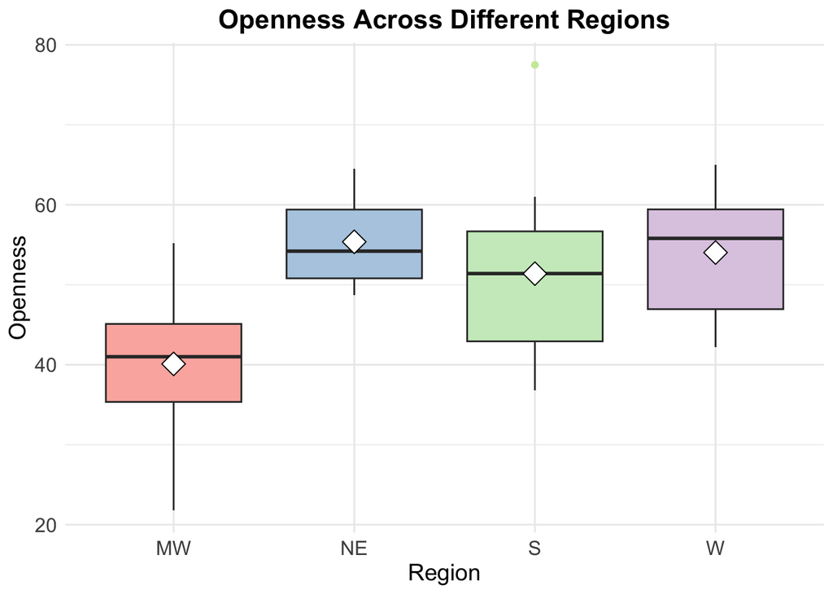

```r
ggplot(oceanData, aes(x = Region, y = O, fill = Region)) +
  geom_boxplot(outlier.color = "#CBEAA6") +
  stat_summary(fun = mean, geom = "point", shape = 23, size = 5, fill = "white", color = "black") +
  labs(
    title = "Openness Across Different Regions",
    x = "Region",
    y = "Openness"
  ) +
  scale_fill_brewer(palette = "Pastel1") +
  theme_minimal() +
  theme(
    plot.title = element_text(size = 16, face = "bold", hjust = 0.5),
    axis.title = element_text(size = 14),
    axis.text = element_text(size = 12),
    legend.position = "none")
```

10. Going back to your original dataset, run an ANOVA to determine if neuroticism (N) differs across region. create a graph to accompany your analysis.

```r
# Run ANOVA
anova_result <- aov(N ~ Region, data = oceanData)
summary(anova_result)
```

```
##             Df Sum Sq Mean Sq F value  Pr(>F)
## Region       3   1964   654.7   10.38 2.6e-05 ***
## Residuals   45   2837    63.1
## ---
## Signif. codes:  0 '***' 0.001 '**' 0.01 '*' 0.05 '.' 0.1 ' ' 1
```

Our ANOVA result is significant, and mean reported neuroticism does differ significantly across regions.

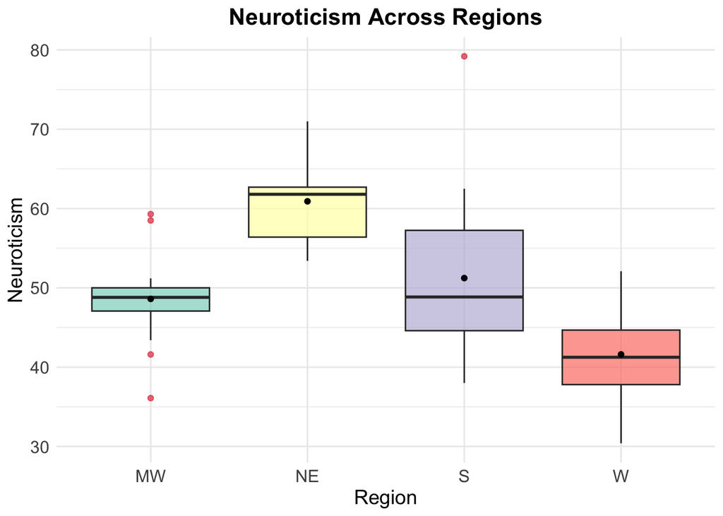

```r
ggplot(oceanData, aes(x = Region, y = N, fill = Region)) +
  geom_boxplot(outlier.color = "#DE3C4B", alpha = 0.7) +
  stat_summary(fun = mean, geom = "point", color = "black", fill = "white") +
  labs(
    title = "Neuroticism Across Regions",
    x = "Region",
    y = "Neuroticism"
  ) +
  scale_fill_brewer(palette = "Set3") +
  theme_minimal() +
  theme(
    plot.title = element_text(size = 16, face = "bold", hjust = 0.5),
    axis.title = element_text(size = 14),
    axis.text = element_text(size = 12),
   legend.position = "none") # suppress since already labeled on x
```